# Project 1 Notebook

```python
% matplotlib inline
```

```python
import matplotlib.pyplot as plt
import pandas as pd
import seaborn
import numpy as np
import requests
from bs4 import BeautifulSoup
```

### Describtion of the data:

```
* State is the most viable Primary Key

* 50 states, Washington DC and the total are included:
    - We need to decide if Washington DC should be included; we will keep it
    - We will remove the 'All' values so it does not corrupt any calculations made

* Understand exactly what 'Rate' we are talking about along with 'Verbal' and 'Math' scores:
    - Rate: State-wide participation in SAT
    - Verbal: mean verbal score per State
    - Math: mean math score per state

* Data types:
    - State is an Object
    - All other columns are Integers
```

```python
df = pd.read_csv('sat_scores.csv')
df.dtypes
```

```
State     object
Rate       int64
Verbal     int64
Math       int64
dtype: object
```

```python
clean_df = df[df.State != 'All'].copy()
clean_df
```

|  | State | Rate | Verbal | Math |
| --- | --- | --- | --- | --- |
| 0 | CT | 82 | 509 | 510 |
| 1 | NJ | 81 | 499 | 513 |
| 2 | MA | 79 | 511 | 515 |
| 3 | NY | 77 | 495 | 505 |
| 4 | NH | 72 | 520 | 516 |
| 5 | RI | 71 | 501 | 499 |
| 6 | PA | 71 | 500 | 499 |
| 7 | VT | 69 | 511 | 506 |
| 8 | ME | 69 | 506 | 500 |
| 9 | VA | 68 | 510 | 501 |
| 10 | DE | 67 | 501 | 499 |
| 11 | MD | 65 | 508 | 510 |
| 12 | NC | 65 | 493 | 499 |
| 13 | GA | 63 | 491 | 489 |
| 14 | IN | 60 | 499 | 501 |
| 15 | SC | 57 | 486 | 488 |
| 16 | DC | 56 | 482 | 474 |
| 17 | OR | 55 | 526 | 526 |
| 18 | FL | 54 | 498 | 499 |
| 19 | WA | 53 | 527 | 527 |
| 20 | TX | 53 | 493 | 499 |
| 21 | HI | 52 | 485 | 515 |
| 22 | AK | 51 | 514 | 510 |
| 23 | CA | 51 | 498 | 517 |
| 24 | AZ | 34 | 523 | 525 |
| 25 | NV | 33 | 509 | 515 |
| 26 | CO | 31 | 539 | 542 |
| 27 | OH | 26 | 534 | 439 |
| 28 | MT | 23 | 539 | 539 |
| 29 | WV | 18 | 527 | 512 |
| 30 | ID | 17 | 543 | 542 |
| 31 | TN | 13 | 562 | 553 |
| 32 | NM | 13 | 551 | 542 |
| 33 | IL | 12 | 576 | 589 |
| 34 | KY | 12 | 550 | 550 |
| 35 | WY | 11 | 547 | 545 |
| 36 | MI | 11 | 561 | 572 |
| 37 | MN | 9 | 580 | 589 |
| 38 | KS | 9 | 577 | 580 |
| 39 | AL | 9 | 559 | 554 |
| 40 | NE | 8 | 562 | 568 |
| 41 | OK | 8 | 567 | 561 |
| 42 | MO | 8 | 577 | 577 |
| 43 | LA | 7 | 564 | 562 |
| 44 | WI | 6 | 584 | 596 |
| 45 | AR | 6 | 562 | 550 |
| 46 | UT | 5 | 575 | 570 |
| 47 | IA | 5 | 593 | 603 |
| 48 | SD | 4 | 577 | 582 |
| 49 | ND | 4 | 592 | 599 |
| 50 | MS | 4 | 566 | 551 |

```python
list_of_states = list(clean_df.State)
list_participation_rates = list(clean_df.Rate)
list_of_list_example = zip(list_of_states, list_participation_rates)
```

```python
clean_df.shape
```

```
(51, 4)
```

```python
clean_df.State.nunique()
```

```
51
```

```python
clean_df.mean()
```

```
Rate       37.000000
Verbal    532.529412
Math      531.843137
dtype: float64
```

```python
clean_df.median()
```

```
Rate       33.0
Verbal    527.0
Math      525.0
dtype: float64
```

```python
clean_df.max()
```

```
State      WY
Rate       82
Verbal    593
Math      603
dtype: object
```

```python
clean_df.min()
```

```
State      AK
Rate        4
Verbal    482
Math      439
dtype: object
```

### Exploring the data through visualisation

Below: Initial matplotlib.pyplot visualisations show evidence of a correlations between high mean scores in both verbal and math scores and low participation rates.

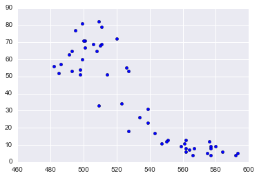

```python
plt.scatter(clean_df.Verbal, clean_df.Rate)
plt.show()
```

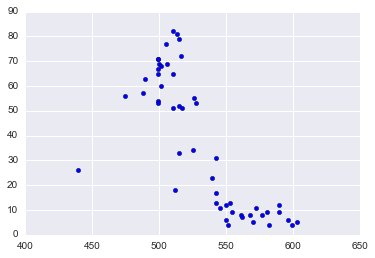

```python
plt.scatter(clean_df.Math, clean_df.Rate)
plt.show()
```

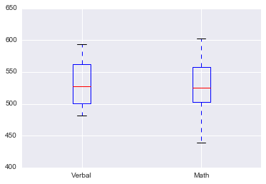

```python
plt.boxplot([clean_df.Verbal, clean_df.Math], labels=['Verbal','Math'])
plt.show()
```

```python
clean_df.Verbal.var()
```

```
1112.934117647059
```

```python
clean_df.Math.var()
```

```
1316.774901960784
```

Below: There is strong evidence of bimodal distribution within the verbal and math means. What does it 'mean'?

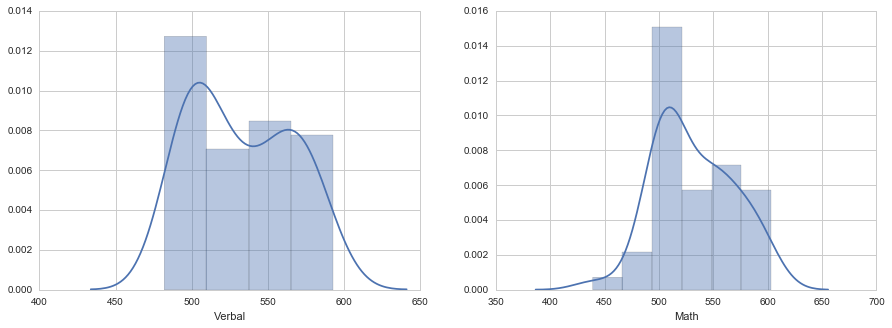

```python
with seaborn.axes_style("whitegrid"):
    fig, axes = plt.subplots(1, 2, figsize=(15,5))
    seaborn.distplot(clean_df.Verbal, ax=axes[0])
    seaborn.distplot(clean_df.Math, ax=axes[1])
fig, axes

plt.show()
```

Below: The kernel density graph below confirms that there are two distinct groups.

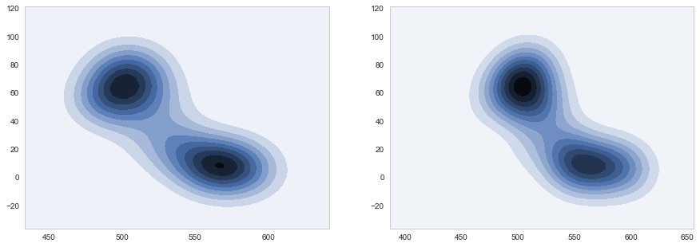

[figure not shown]

[figure not shown]

```python
with seaborn.axes_style("whitegrid"):
    fig, axes = plt.subplots(1, 2, figsize=(15,5))
    seaborn.jointplot(x="Verbal", y="Rate", kind="kde", data=clean_df, ax=axes[0])
    seaborn.jointplot(x="Math", y="Rate", kind="kde", data=clean_df, ax=axes[1])

fig, axes

plt.show()
```

### Define the two distinct groups

The groups are defined as having a participationg rate greater than 40 or not.

```python
rate_greater_than_fourty = clean_df.Rate > 40
clean_df['rate_greater_than_40'] = rate_greater_than_fourty
```

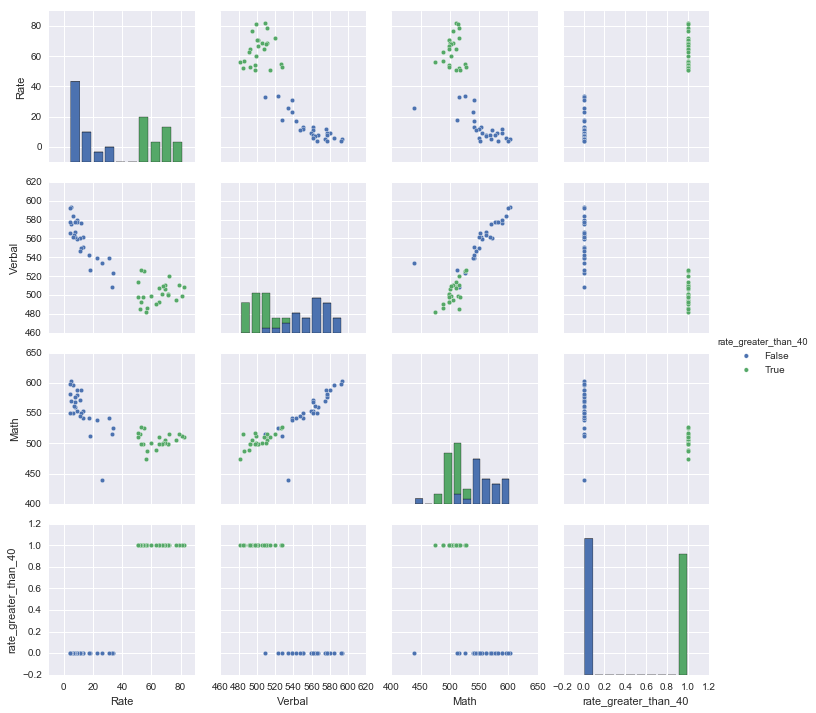

```python
seaborn.pairplot(data=clean_df, hue='rate_greater_than_40')
plt.show()
```

Below: States with a participation rate greater than 40 tend to have lower mean scores for both verbal and math tests. Also, thos states tend to have a tighter distribution of scores. Conversely, the distribution of scores of States under 40 is much greater. This may suggest greater homogeneity amongst States with greater participation rates.

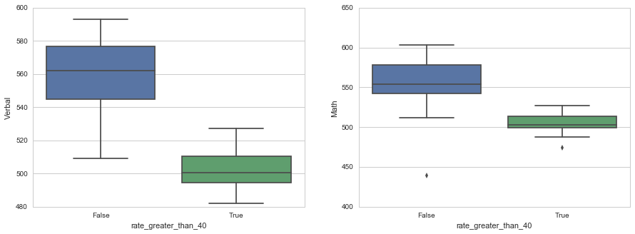

```python
with seaborn.axes_style("whitegrid"):
    fig, axes = plt.subplots(1, 2, figsize=(15,5))
    seaborn.boxplot(x='rate_greater_than_40', y='Verbal', data=clean_df, ax=axes[0])
    seaborn.boxplot(x='rate_greater_than_40', y='Math', data=clean_df, ax=axes[1])

fig, axes

plt.show()
```

### Pull external information into the dataset

This will help create a robust analyse of the SAT scores and participation rate, and hopefully bring some understanding to the bimodal distribution seen above.

```
Investigate the impact of the following on SAT scores and participation rate:

* State population
* Agriculture
```

##### Impact of State population

```python
url = 'https://people.sc.fsu.edu/~jburkardt/datasets/census/census_2010.txt'
req = requests.get(url)
```

```python
US_States = []
State_Pop = []

for line in req.text.split('\n'):
    if line != '':
        US_States.append((line[0:2]))
        pop = int(line[4:].replace(',','').replace(' ', '').replace('\t', '').encode('utf-8'))
        State_Pop.append(pop)

State_Pop_Table = zip(US_States, State_Pop)

State_Pop_DF = pd.DataFrame(data=State_Pop_Table, columns=('US_States','State_Pop'))
```

```python
df_w_pop = clean_df.merge(State_Pop_DF, how='left', left_on=clean_df.State, right_on=State_Pop_DF.US_States).copy()
```

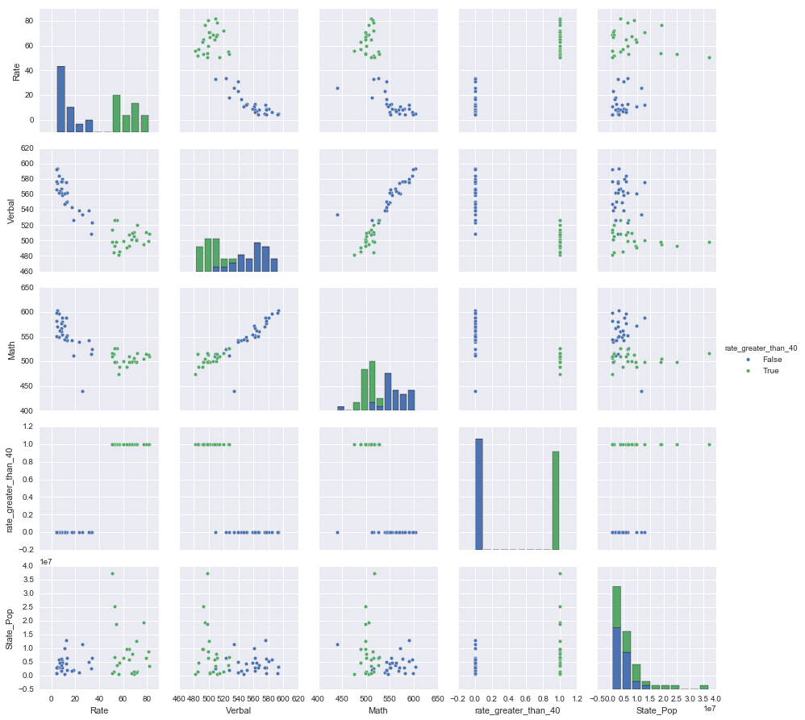

```python
seaborn.pairplot(data=df_w_pop, hue='rate_greater_than_40')
plt.show()
```

Below: Population does not correlate to participation rate.

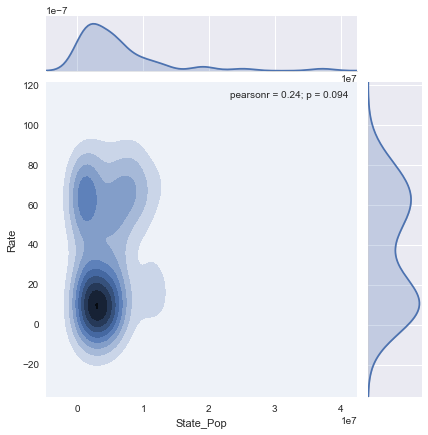

```python
seaborn.jointplot(x='State_Pop', y='Rate', kind="kde", data=df_w_pop)
plt.show()
```

Below: This lack of correlation to population holds true even when the data is subset into groups greater and less than 40% participation.

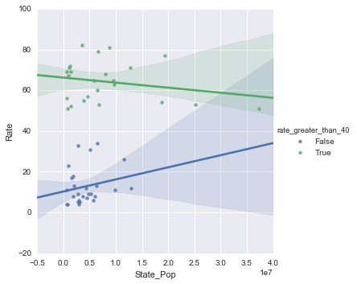

```python
seaborn.lmplot(x='State_Pop', y='Rate', data=df_w_pop, hue='rate_greater_than_40')
plt.show()
```

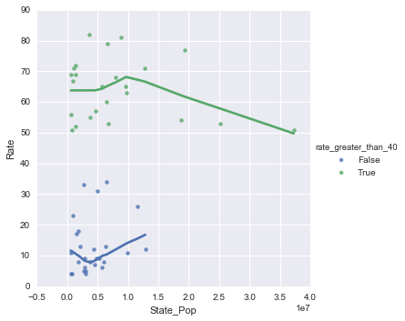

```python
seaborn.lmplot(x="State_Pop", y="Rate", data=df_w_pop, lowess=True, hue="rate_greater_than_40")
plt.show()
```

Below: There is, however, less variation of population size amongs state with a participation rate below 40.

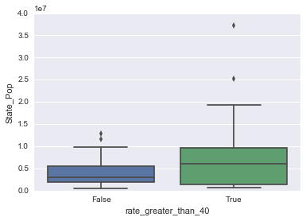

```python
seaborn.boxplot(x='rate_greater_than_40', y='State_Pop', data=df_w_pop)
plt.show()
```

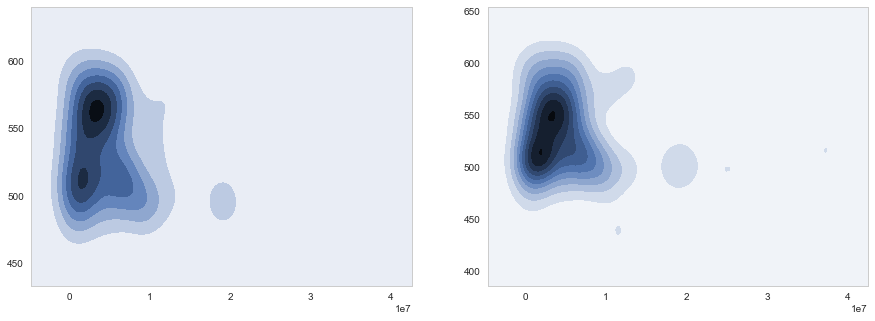

[figure not shown]

[figure not shown]

```python
with seaborn.axes_style("whitegrid"):
    fig, axes = plt.subplots(1, 2, figsize=(15,5))
    seaborn.jointplot(x="State_Pop", y="Verbal", kind="kde", data=df_w_pop, ax=axes[0])
    seaborn.jointplot(x="State_Pop", y="Math", kind="kde", data=df_w_pop, ax=axes[1])

fig, axes

plt.show()
```

##### Impact of agriculture

```python
ag_data = pd.read_excel('FSA_Crop_National_Data_2011-15.xlsx')
```

```python
df_w_ag = df_w_pop.merge(ag_data, how='left', on='State')
```

```python
df_w_ag['Planted_Acres_per_Capita'] = df_w_ag.Planted_Acres_y / df_w_ag.State_Pop
```

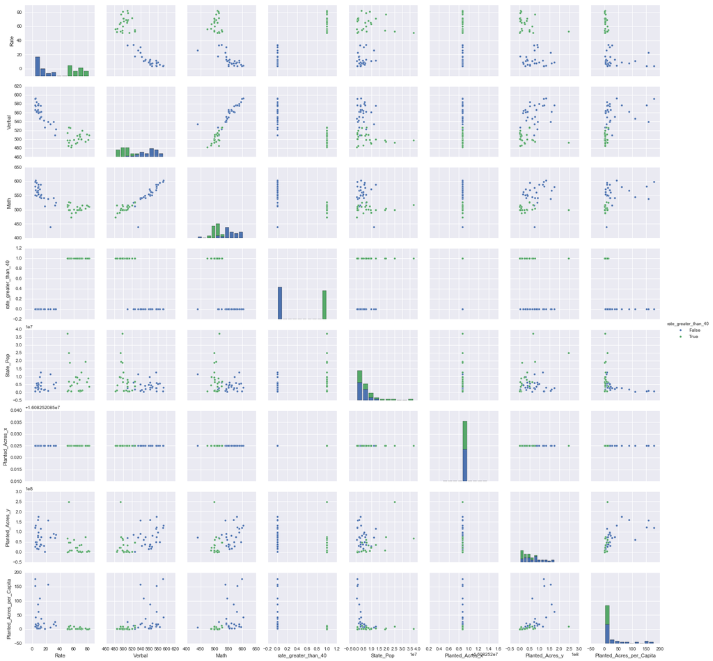

```python
seaborn.pairplot(data=df_w_ag, hue='rate_greater_than_40')
plt.show()
```

Below: The figure below clearly illustrates that States with high participation rates do not have high amounts of agriculture per capita (i.e. agriculture probably does not play a huge role in the economy).

Conversely, many States with low participation rates appear to have high amounts of agriculture per capita; this should be tempered by the fact that the distribution of agriculture per capita amongs low-participation states may mean agriculture does not always effect participation rate.

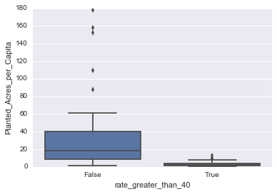

```python
seaborn.boxplot(y='Planted_Acres_per_Capita', x='rate_greater_than_40', data=df_w_ag)
plt.show()
```

##### Deeper analysis of low participation rate States.

```python
low_rate_states = pd.DataFrame(df_w_ag[df_w_ag.rate_greater_than_40 == False])
```

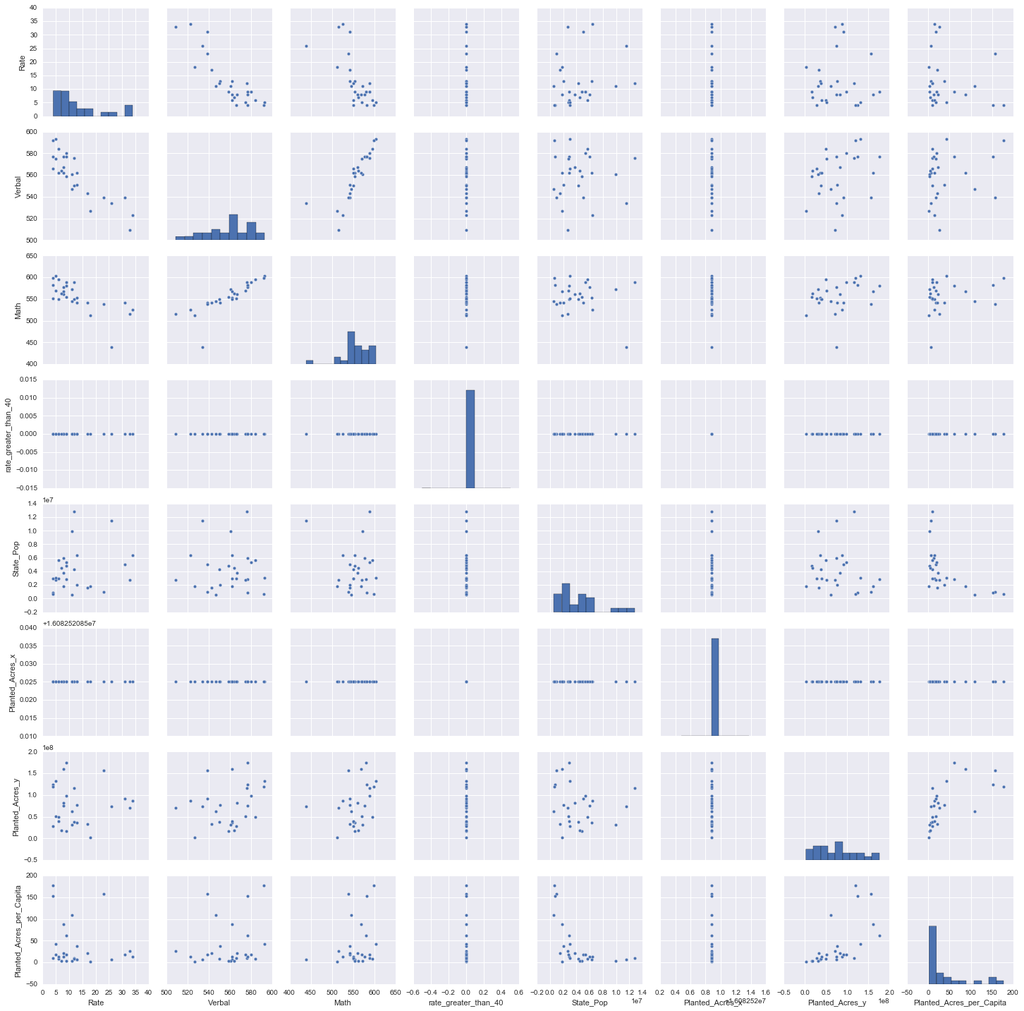

```python
seaborn.pairplot(data=low_rate_states)
plt.show()
```

Below: Note the cluster of states with low participation rate and low levels of agriculture. This does not support the idea that agriculture plays a significant role in high or low participation rates.

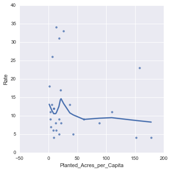

```python
seaborn.lmplot(x="Planted_Acres_per_Capita", y="Rate", data=low_rate_states, lowess=True)
plt.show()
```

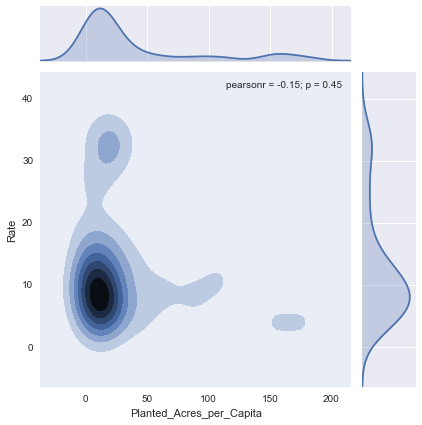

```python
seaborn.jointplot(x="Planted_Acres_per_Capita", y="Rate", data=low_rate_states, kind='kde')
plt.show()
```

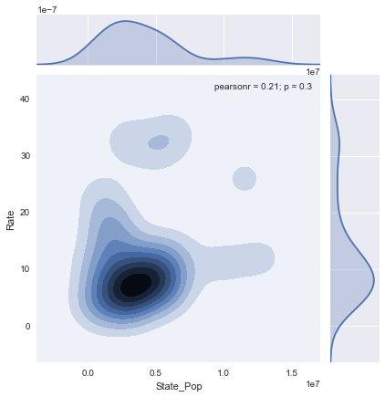

```python
seaborn.jointplot(x="State_Pop", y="Rate", data=low_rate_states, kind='kde')
plt.show()
```

### Map visualisations

It is clear that agriculture may play a role in participation rates. It is clear that it does not play a role in higher participation rates, but the shape of agriculture's role in States with lower rates is unclear.

At this point we feel it would be appropriate to visualise this dataset on a map of the United Sates. We will does this using Tableau. This may help catalyse ideas for what drives participation rates in high-rate States, and what role agriculture and other factors may play in low-rate States.

See the Tableau dashboard visualisation here: https://public.tableau.com/profile/publish/DSI1_Project1_Byron_Allen/DSI1_Project1#!/publish-confirm

```python
df_w_ag.to_csv(path_or_buf='df_w_ag.csv')
```

```python
df_w_ag
```

|  | State | Rate | Verbal | Math | rate_greater_than_40 | US_States | State_Pop | Planted_Acres_x | Planted_Acres_y | Planted_Acres_per_Capita |
| --- | --- | --- | --- | --- | --- | --- | --- | --- | --- | --- |
| 0 | CT | 82 | 509 | 510 | True | CT | 3574097 | 1.608252e+07 | 4.358388e+06 | 1.219438 |
| 1 | NJ | 81 | 499 | 513 | True | NJ | 8791894 | 1.608252e+07 | 7.227234e+06 | 0.822034 |
| 2 | MA | 79 | 511 | 515 | True | MA | 6547629 | 1.608252e+07 | 1.354221e+06 | 0.206826 |
| 3 | NY | 77 | 495 | 505 | True | NY | 19378102 | 1.608252e+07 | 7.517629e+07 | 3.879446 |
| 4 | NH | 72 | 520 | 516 | True | NH | 1316470 | 1.608252e+07 | 1.846348e+06 | 1.402499 |
| 5 | RI | 71 | 501 | 499 | True | RI | 1052567 | 1.608252e+07 | 2.375515e+05 | 0.225688 |
| 6 | PA | 71 | 500 | 499 | True | PA | 12702379 | 1.608252e+07 | 3.709844e+07 | 2.920590 |
| 7 | VT | 69 | 511 | 506 | True | VT | 625741 | 1.608252e+07 | 5.147201e+06 | 8.225769 |
| 8 | ME | 69 | 506 | 500 | True | ME | 1328361 | 1.608252e+07 | 3.027834e+06 | 2.279376 |
| 9 | VA | 68 | 510 | 501 | True | VA | 8001024 | 1.608252e+07 | 3.346209e+07 | 4.182225 |
| 10 | DE | 67 | 501 | 499 | True | DE | 897934 | 1.608252e+07 | 2.147917e+06 | 2.392066 |
| 11 | MD | 65 | 508 | 510 | True | MD | 5773552 | 1.608252e+07 | 9.460060e+06 | 1.638516 |
| 12 | NC | 65 | 493 | 499 | True | NC | 9535483 | 1.608252e+07 | 2.340877e+07 | 2.454912 |
| 13 | GA | 63 | 491 | 489 | True | GA | 9687653 | 1.608252e+07 | 2.392265e+07 | 2.469396 |
| 14 | IN | 60 | 499 | 501 | True | IN | 6483802 | 1.608252e+07 | 6.204987e+07 | 9.569983 |
| 15 | SC | 57 | 486 | 488 | True | SC | 4625364 | 1.608252e+07 | 9.624547e+06 | 2.080819 |
| 16 | DC | 56 | 482 | 474 | True | DC | 601723 | 1.608252e+07 | NaN | NaN |
| 17 | OR | 55 | 526 | 526 | True | OR | 3831074 | 1.608252e+07 | 4.869916e+07 | 12.711621 |
| 18 | FL | 54 | 498 | 499 | True | FL | 18801310 | 1.608252e+07 | 1.003854e+07 | 0.533928 |
| 19 | WA | 53 | 527 | 527 | True | WA | 6724540 | 1.608252e+07 | 4.816364e+07 | 7.162369 |
| 20 | TX | 53 | 493 | 499 | True | TX | 25145561 | 1.608252e+07 | 2.473212e+08 | 9.835583 |
| 21 | HI | 52 | 485 | 515 | True | HI | 1360301 | 1.608252e+07 | 1.368522e+06 | 1.006044 |
| 22 | AK | 51 | 514 | 510 | True | AK | 710231 | 1.608252e+07 | 1.947661e+05 | 0.274229 |
| 23 | CA | 51 | 498 | 517 | True | CA | 37253956 | 1.608252e+07 | 6.742826e+07 | 1.809962 |
| 24 | AZ | 34 | 523 | 525 | False | AZ | 6392017 | 1.608252e+07 | 8.704252e+07 | 13.617379 |
| 25 | NV | 33 | 509 | 515 | False | NV | 2700551 | 1.608252e+07 | 7.114914e+07 | 26.346158 |
| 26 | CO | 31 | 539 | 542 | False | CO | 5029196 | 1.608252e+07 | 9.110750e+07 | 18.115719 |
| 27 | OH | 26 | 534 | 439 | False | OH | 11536504 | 1.608252e+07 | 7.388135e+07 | 6.404136 |
| 28 | MT | 23 | 539 | 539 | False | MT | 989415 | 1.608252e+07 | 1.563404e+08 | 158.012940 |
| 29 | WV | 18 | 527 | 512 | False | WV | 1852994 | 1.608252e+07 | 2.463088e+06 | 1.329248 |
| 30 | ID | 17 | 543 | 542 | False | ID | 1567582 | 1.608252e+07 | 3.235019e+07 | 20.637001 |
| 31 | TN | 13 | 562 | 553 | False | TN | 6346165 | 1.608252e+07 | 3.659717e+07 | 5.766817 |
| 32 | NM | 13 | 551 | 542 | False | NM | 2059179 | 1.608252e+07 | 7.638790e+07 | 37.096287 |
| 33 | IL | 12 | 576 | 589 | False | IL | 12830632 | 1.608252e+07 | 1.167334e+08 | 9.098023 |
| 34 | KY | 12 | 550 | 550 | False | KY | 4339367 | 1.608252e+07 | 3.862692e+07 | 8.901511 |
| 35 | WY | 11 | 547 | 545 | False | WY | 563626 | 1.608252e+07 | 6.180641e+07 | 109.658549 |
| 36 | MI | 11 | 561 | 572 | False | MI | 9883640 | 1.608252e+07 | 3.076994e+07 | 3.113219 |
| 37 | MN | 9 | 580 | 589 | False | MN | 5303925 | 1.608252e+07 | 9.829078e+07 | 18.531706 |
| 38 | KS | 9 | 577 | 580 | False | KS | 2853118 | 1.608252e+07 | 1.751495e+08 | 61.388820 |
| 39 | AL | 9 | 559 | 554 | False | AL | 4779736 | 1.608252e+07 | 1.608252e+07 | 3.364730 |
| 40 | NE | 8 | 562 | 568 | False | NE | 1826341 | 1.608252e+07 | 1.604709e+08 | 87.864695 |
| 41 | OK | 8 | 567 | 561 | False | OK | 3751351 | 1.608252e+07 | 8.206404e+07 | 21.875863 |
| 42 | MO | 8 | 577 | 577 | False | MO | 5988144 | 1.608252e+07 | 7.468785e+07 | 12.472621 |
| 43 | LA | 7 | 564 | 562 | False | LA | 4533372 | 1.608252e+07 | 1.828470e+07 | 4.033355 |
| 44 | WI | 6 | 584 | 596 | False | WI | 5686986 | 1.608252e+07 | 4.954619e+07 | 8.712205 |
| 45 | AR | 6 | 562 | 550 | False | AR | 2915918 | 1.608252e+07 | 3.964353e+07 | 13.595558 |
| 46 | UT | 5 | 575 | 570 | False | UT | 2763885 | 1.608252e+07 | 5.060936e+07 | 18.310950 |
| 47 | IA | 5 | 593 | 603 | False | IA | 3046355 | 1.608252e+07 | 1.314365e+08 | 43.145512 |
| 48 | SD | 4 | 577 | 582 | False | SD | 814180 | 1.608252e+07 | 1.239256e+08 | 152.209132 |
| 49 | ND | 4 | 592 | 599 | False | ND | 672591 | 1.608252e+07 | 1.197693e+08 | 178.071587 |
| 50 | MS | 4 | 566 | 551 | False | MS | 2967297 | 1.608252e+07 | 2.787419e+07 | 9.393800 |